# R Notebook

1)Write a function that adds two numbers, and divides the result by 2.

```r
print("Add two numbers")
```

```
[1] "Add two numbers"
```

```r
add = function(x, y){
  return(x+y)
}
z=add(5, 6)
print(z)
```

```
[1] 11
```

```r
paste("divides the result by 2 = ", z/2)
```

```
[1] "divides the result by 2 =  5.5"
```

2)Write a function called first Two Chars that extracts the first two characters of any bit of text.

```r
print("Extracts the first two characters")
```

```
[1] "Extracts the first two characters"
```

```r
Txt= "Good Morning Everyone"
substr(Txt, start = 1, stop = 2)
```

```
[1] "Go"
```

3)Write a function that checks if there are any missing values in a vector.(if missing then returnsTRUE , otherwise FALSE)

```r
a <- c(1, 2, NA, 4)
a
```

```
[1]  1  2 NA  4
```

```r
print("checks if there are any missing values in a vector.if missing then returnsTRUE , otherwise FALSE")
```

```
[1] "checks if there are any missing values in a vector.if missing then returnsTRUE , otherwise FALSE"
```

```r
is.na(a)
```

```
[1] FALSE FALSE  TRUE FALSE
```

4)Write the function so that it tells you which of the values are missing.

```r
a <- c(1, 2, NA, 4, 7, NA, 9, NA)
a
```

```
[1]  1  2 NA  4  7 NA  9 NA
```

```r
is.na(a)
```

```
[1] FALSE FALSE  TRUE FALSE FALSE  TRUE FALSE  TRUE
```

```r
print("index of missing values in vector: ")
```

```
[1] "index of missing values in vector: "
```

```r
which(is.na(a))
```

```
[1] 3 6 8
```

5)Write a function that returns the confidence interval for a vector. The function should have two inputs: the vector, and the desired ’alpha’.

```r
calculateCI <- function(x, alpha=0.09){
xbar <- mean(x)
s <- sd(x)
n <- length(x)
half.width <- qt(1-alpha/2, n-1)*s/sqrt(n)
# Confidence Interval
CI <- c(xbar - half.width, xbar + half.width)
return(CI)
}
calculateCI(rnorm(100))
```

```
[1] -0.28047939  0.06600197
```

6. Write a function call middle that shows a few rows around (approx.) the ’middle’ of the dataset. Hint: use nrow, print, and possibly floor.

```r
# Shows ten rows AROUND middle
middle <- function(x, n=10){
96
m <- floor(nrow(x)/2)
start <- floor(m - n/2)
end <- ceiling(m + n/2)-1
sub <- x[start:end,]
print(sub)
}
```

7)First read the following list: veclist <- list(x=1:5, y=2:6, z=3:7) Using sapply, check that all elements of the list are vectors of the same length. Also calculate the sum of each element.

```r
veclist <- list(x=1:5, y=2:6, z=3:7)
veclist
```

```
$x
[1] 1 2 3 4 5

$y
[1] 2 3 4 5 6

$z
[1] 3 4 5 6 7
```

```r
print("check that all elements of the list are vectors of the same length: ")
```

```
[1] "check that all elements of the list are vectors of the same length: "
```

```r
length(veclist)
```

```
[1] 3
```

```r
sapply(veclist, length)
```

```
x y z
5 5 5
```

```r
print("sum of each element in the list: ")
```

```
[1] "sum of each element in the list: "
```

```r
sapply(veclist, sum)
```

```
 x  y  z
15 20 25
```

8)Using the pupae data , use a t-test to find if PupalWeight varies with temperature treatment, separate for the two CO2 treatments (so, do two t-tests). Use split and lapply.

| T_treatment | CO2_treatment | Gender | PupalWeight | Frass |
| --- | --- | --- | --- | --- |
| ambient | 280 | 0 | 0.244 | 1.900 |
| ambient | 280 | 1 | 0.319 | 2.770 |
| ambient | 280 | 0 | 0.221 | NA |
| ambient | 280 | 0 | 0.280 | 1.996 |
| ambient | 280 | 0 | 0.257 | 1.069 |
| ambient | 280 | 1 | 0.333 | 2.257 |
| ambient | 280 | 0 | 0.275 | 2.198 |
| ambient | 280 | 1 | 0.312 | 1.873 |
| ambient | 280 | 0 | 0.254 | 2.220 |
| ambient | 280 | 1 | 0.356 | 1.807 |

[output cut: 74 more lines]

```r
pupae <- read.csv("pupae.csv")
pupae


pupae_sp <- split(pupae, pupae$CO2_treatment)
lapply(pupae_sp, function(x)t.test(PupalWeight ~ T_treatment, data=x))
```

```
$`280`

    Welch Two Sample t-test

data:  PupalWeight by T_treatment
t = -0.81696, df = 31.012, p-value = 0.4202
alternative hypothesis: true difference in means is not equal to 0
95 percent confidence interval:
 -0.0521665  0.0223265
sample estimates:
 mean in group ambient mean in group elevated
               0.29000                0.30492


$`400`

    Welch Two Sample t-test

data:  PupalWeight by T_treatment
t = 2.1824, df = 42.886, p-value = 0.0346
alternative hypothesis: true difference in means is not equal to 0
95 percent confidence interval:
 0.003259507 0.082653536
sample estimates:
 mean in group ambient mean in group elevated
             0.3419565              0.2990000
```

9)First read the data. Then, split the data by species, to produce a list called coweeta_sp. Keep only those species that have at least 1o observations. (Hint: first count the number of observations per species, save that as a vector, find which are at least 1o, and use that to subscript the list.)

```r
coweeta <- read.csv("coweeta.csv")
coweeta
```

| species | site | elev | age | DBH | height | folmass | SLA | biomass |
| --- | --- | --- | --- | --- | --- | --- | --- | --- |
| acru | mulb | 884 | 53 | 6.3 | 10.32 | 0.41 | 163.03 | 11.00 |
| acru | mulb | 884 | 55 | 10.4 | 13.85 | 1.65 | 131.59 | 34.96 |
| acru | mulb | 884 | 46 | 12.9 | 16.50 | 2.49 | 153.93 | 69.48 |
| acru | mulb | 884 | 64 | 13.4 | 17.88 | 2.57 | 149.59 | 65.64 |
| acru | mulb | 884 | 61 | 14.6 | 18.80 | 3.36 | 111.91 | 83.11 |
| acru | mulb | 884 | 71 | 15.1 | 14.52 | 2.73 | 148.81 | 86.95 |
| acru | brkscove | 914 | 59 | 21.0 | 19.60 | 8.76 | 164.33 | 193.17 |
| acru | ballcrcv | 732 | 110 | 26.5 | 26.34 | 7.82 | 152.67 | 425.39 |
| acru | dykegap | 793 | 76 | 36.9 | 27.00 | 21.11 | 120.04 | 948.08 |
| acru | dykegap | 793 | 135 | 45.1 | 33.55 | 12.75 | 143.49 | 1653.64 |

[output cut: 77 more lines]

```r
# Make list of dataframes
coweeta_sp <- split(coweeta, coweeta$species)

# Keep only species with at least 10 observations
nspec <- sapply(coweeta_sp,nrow) # count number of species
morethan10 <- nspec > 9 # logical vector, TRUE when nspec > 9

# Use that to index the list (with single square bracket!!!)
coweeta_sp <- coweeta_sp[morethan10]
```

10)Using the split Coweeta data, perform a linear regression of log10(biomass) on log10(height) Separated by species.

```r
lms <- lapply(coweeta_sp, function(x)lm(log10(biomass) ~ log10(height),data=x))
```

11)Run this code to get two vectors: x <- rnorm(100) y <- x + rnorm(100) Run a linear regression y = f(x), save the resulting object. Look at the structure of this object, and note the names of the elements. Extract the residuals and make a histogram.

```r
x <- rnorm(100)
y <- x + rnorm(100)
O <- lm(y ~ x)
str(O)
```

```
List of 12
 $ coefficients : Named num [1:2] -0.00973 1.01817
  ..- attr(*, "names")= chr [1:2] "(Intercept)" "x"
 $ residuals    : Named num [1:100] 1.925 1.245 0.725 -0.403 1.763 ...
  ..- attr(*, "names")= chr [1:100] "1" "2" "3" "4" ...
 $ effects      : Named num [1:100] -1.51 -9.75 0.722 -0.626 1.597 ...
  ..- attr(*, "names")= chr [1:100] "(Intercept)" "x" "" "" ...
 $ rank         : int 2
 $ fitted.values: Named num [1:100] -0.343 0.391 -1.509 0.562 0.022 ...
  ..- attr(*, "names")= chr [1:100] "1" "2" "3" "4" ...
 $ assign       : int [1:2] 0 1
 $ qr           :List of 5
  ..$ qr   : num [1:100, 1:2] -10 0.1 0.1 0.1 0.1 0.1 0.1 0.1 0.1 0.1 ...
  .. ..- attr(*, "dimnames")=List of 2
  .. .. ..$ : chr [1:100] "1" "2" "3" "4" ...
  .. .. ..$ : chr [1:2] "(Intercept)" "x"
  .. ..- attr(*, "assign")= int [1:2] 0 1
  ..$ qraux: num [1:2] 1.1 1.03
  ..$ pivot: int [1:2] 1 2
  ..$ tol  : num 1e-07
  ..$ rank : int 2
  ..- attr(*, "class")= chr "qr"
 $ df.residual  : int 98
 $ xlevels      : Named list()
 $ call         : language lm(formula = y ~ x)
 $ terms        :Classes 'terms', 'formula'  language y ~ x
  .. ..- attr(*, "variables")= language list(y, x)
  .. ..- attr(*, "factors")= int [1:2, 1] 0 1
  .. .. ..- attr(*, "dimnames")=List of 2
  .. .. .. ..$ : chr [1:2] "y" "x"
  .. .. .. ..$ : chr "x"
  .. ..- attr(*, "term.labels")= chr "x"
  .. ..- attr(*, "order")= int 1
  .. ..- attr(*, "intercept")= int 1
  .. ..- attr(*, "response")= int 1
  .. ..- attr(*, ".Environment")=<environment: R_GlobalEnv>
  .. ..- attr(*, "predvars")= language list(y, x)
  .. ..- attr(*, "dataClasses")= Named chr [1:2] "numeric" "numeric"
  .. .. ..- attr(*, "names")= chr [1:2] "y" "x"
 $ model        :'data.frame':  100 obs. of  2 variables:
  ..$ y: num [1:100] 1.582 1.637 -0.784 0.159 1.785 ...
  ..$ x: num [1:100] -0.3272 0.3938 -1.4723 0.5616 0.0312 ...
  ..- attr(*, "terms")=Classes 'terms', 'formula'  language y ~ x
  .. .. ..- attr(*, "variables")= language list(y, x)
  .. .. ..- attr(*, "factors")= int [1:2, 1] 0 1
  .. .. .. ..- attr(*, "dimnames")=List of 2
  .. .. .. .. ..$ : chr [1:2] "y" "x"
  .. .. .. .. ..$ : chr "x"
  .. .. ..- attr(*, "term.labels")= chr "x"
  .. .. ..- attr(*, "order")= int 1
  .. .. ..- attr(*, "intercept")= int 1
  .. .. ..- attr(*, "response")= int 1
  .. .. ..- attr(*, ".Environment")=<environment: R_GlobalEnv>
  .. .. ..- attr(*, "predvars")= language list(y, x)
  .. .. ..- attr(*, "dataClasses")= Named chr [1:2] "numeric" "numeric"
  .. .. .. ..- attr(*, "names")= chr [1:2] "y" "x"
 - attr(*, "class")= chr "lm"
```

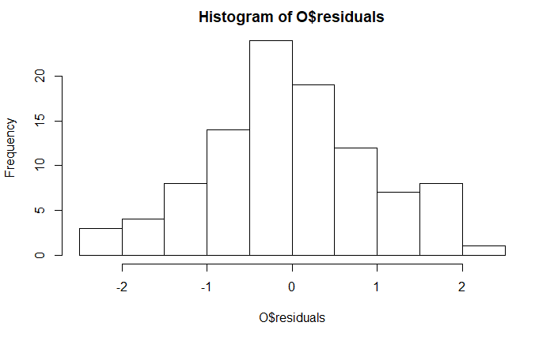

```r
hist(O$residuals)
```

```r
lmfit <- O
```

12)From question above, write a function that takes an lm object as an argument, and plots a histogram Of the residuals.

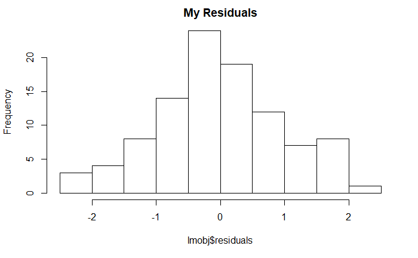

```r
lmResidHist <- function(lmobj){
100
hist(lmobj$residuals)
}
# better:
# You can now use any argument that hist() recognizes,
# they are passed through the use of '...'
lmResidHist <- function(lmobj,...){
hist(lmobj$residuals,...)
}
lmResidHist(lmfit, main="My Residuals")
```

13)Read the cereal data. Create a subset of data where the Manufacturer has at least two observations (use table to find out which you want to keep first). Don’t forget to drop the empty factor level you may have created!

```r
cereal <- read.csv("cereals.csv")
tab <- table(cereal$Manufacturer)
morethan1 <- names(tab)[tab > 1]
cereal_2 <- droplevels(subset(cereal, Manufacturer %in% morethan1))
cereal_2
```

|  | Cereal.name | Manufacturer | Cold.or.Hot | calories | protein | fat | sodium | fiber | carbo | sugars | potass | vitamins | rating |
| --- | --- | --- | --- | --- | --- | --- | --- | --- | --- | --- | --- | --- | --- |
| 1 | 100%_Bran | N | C | 70 | 4 | 1 | 130 | 10.0 | 5.0 | 6 | 280 | 25 | 68.40297 |
| 2 | 100%_Natural_Bran | Q | C | 120 | 3 | 5 | 15 | 2.0 | 8.0 | 8 | 135 | 0 | 33.98368 |
| 3 | All-Bran | K | C | 70 | 4 | 1 | 260 | 9.0 | 7.0 | 5 | 320 | 25 | 59.42551 |
| 4 | All-Bran_with_Extra_Fiber | K | C | 50 | 4 | 0 | 140 | 14.0 | 8.0 | 0 | 330 | 25 | 93.70491 |
| 5 | Almond_Delight | R | C | 110 | 2 | 2 | 200 | 1.0 | 14.0 | 8 | NA | 25 | 34.38484 |
| 6 | Apple_Cinnamon_Cheerios | G | C | 110 | 2 | 2 | 180 | 1.5 | 10.5 | 10 | 70 | 25 | 29.50954 |
| 7 | Apple_Jacks | K | C | 110 | 2 | 0 | 125 | 1.0 | 11.0 | 14 | 30 | 25 | 33.17409 |
| 8 | Basic_4 | G | C | 130 | 3 | 2 | 210 | 2.0 | 18.0 | 8 | 100 | 25 | 37.03856 |
| 9 | Bran_Chex | R | C | 90 | 2 | 1 | 200 | 4.0 | 15.0 | 6 | 125 | 25 | 49.12025 |
| 10 | Bran_Flakes | P | C | 90 | 3 | 0 | 210 | 5.0 | 13.0 | 5 | 190 | 25 | 53.31381 |

[output cut: 66 more lines]

14)Make a single PDF with six plots, with a scatter plot between potassium and fiber for each of the six (or seven?) Manufacturers.

```r
cerealsp <- split(cereal, cereal$Manufacturer)
pdf("cereal plots.pdf", onefile=TRUE)
for(i in 1:length(cerealsp)){
with(cerealsp[[i]],
plot(potass, fiber, main=names(cerealsp)[i])
)
}
dev.off()
```

15)Using Dutch election data , read the data and convert date variable.

```r
election <- read.csv("dutchelection.csv")
election
```

| Date | VVD | PvdA | PVV | CDA | SP | D66 | GL | CU | SGP | PvdD | FiftyPlus |
| --- | --- | --- | --- | --- | --- | --- | --- | --- | --- | --- | --- |
| 2012-03-22 | 22.1 | 16.8 | 13.9 | 9.4 | 16.8 | 7.7 | 4.5 | 3.3 | 1.5 | 2.4 | 1.1 |
| 2012-04-05 | 23.6 | 17.1 | 13.3 | 8.8 | 16.3 | 8.7 | 4.1 | 3.2 | 1.4 | 2.0 | 0.8 |
| 2012-04-19 | 24.0 | 17.3 | 12.0 | 8.2 | 17.0 | 8.8 | 3.5 | 3.3 | 1.6 | 3.1 | 0.8 |
| 2012-04-27 | 22.4 | 16.5 | 12.1 | 8.4 | 17.2 | 10.6 | 3.3 | 4.0 | 1.7 | 2.2 | 0.8 |
| 2012-05-05 | 22.9 | 14.7 | 11.4 | 9.0 | 18.5 | 10.1 | 4.1 | 3.6 | 1.4 | 2.9 | 0.8 |
| 2012-05-12 | 21.4 | 14.5 | 12.7 | 10.3 | 18.5 | 9.9 | 3.8 | 3.9 | 1.3 | 2.5 | 0.8 |
| 2012-05-18 | 20.1 | 16.0 | 13.8 | 10.7 | 17.3 | 9.8 | 3.8 | 3.4 | 1.4 | 2.5 | 0.7 |
| 2012-05-25 | 19.8 | 16.2 | 13.4 | 10.3 | 17.5 | 10.3 | 3.8 | 3.7 | 1.4 | 2.3 | 0.8 |
| 2012-06-02 | 21.0 | 15.3 | 14.1 | 9.4 | 17.6 | 9.7 | 3.7 | 3.4 | 1.6 | 2.3 | 0.8 |
| 2012-06-15 | 22.3 | 15.5 | 15.3 | 8.0 | 16.6 | 9.6 | 3.3 | 4.0 | 1.4 | 2.1 | 0.7 |

[output cut: 12 more lines]

```r
con_Date <- as.Date(election$Date)
con_Date
```

```
 [1] "2012-03-22" "2012-04-05" "2012-04-19" "2012-04-27" "2012-05-05" "2012-05-12" "2012-05-18" "2012-05-25"
 [9] "2012-06-02" "2012-06-15" "2012-06-29" "2012-07-06" "2012-07-13" "2012-07-27" "2012-08-10" "2012-08-17"
[17] "2012-08-24" "2012-08-31" "2012-09-03" "2012-09-05" "2012-09-08" "2012-09-11"
```

16)Write a function that adds lines for each of the parties in the election data to a plot.

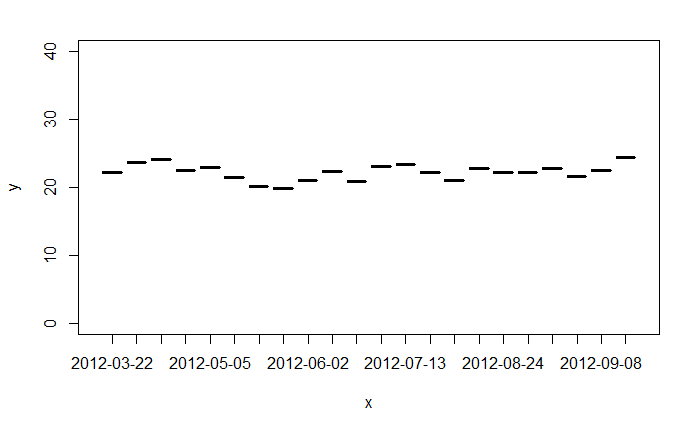

```r
with(election, plot(Date, VVD, type='n', ylim=c(0,40)))
```

17)Loop through all columns of the election data, add a line for each column to the plot.

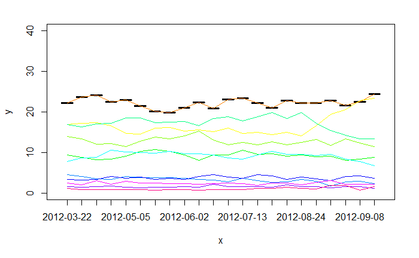

```r
palette(rainbow(12))
addline <- function(columnnr, colour){
Y <- election[,columnnr]
X <- election$Date
lines(X,Y, col=colour)
}
with(election, plot(Date, VVD, type='n', ylim=c(0,40)))
# Be careful: poll results are in columns 2 to 12
for(i in 2:12)addline(i,colour=palette()[i])
```

18)For the HFE weather dataset , write a function that makes a scatter plot between PAR and VPD

```r
# This function works for any dataframe, as long as it has
# columns names 'PAR' or 'VPD' in it.
PARVPD <- function(dat){
with(dat, plot(PAR, VPD))
}
```

19)Then, split the dataset by month, and make twelve such scatter plots. Save the result in a single PDF, or on one page with 12 small figures.

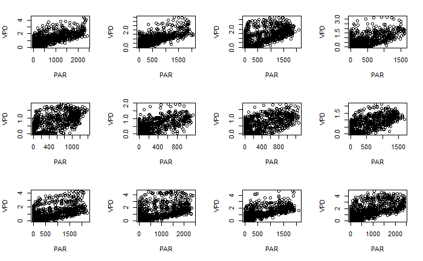

```r
hfe <- read.csv("HFEmet2008.csv")

library(lubridate)
hfe$DateTime <- mdy_hm(as.character(hfe$DateTime))
# extract month,
hfe$month <- month(hfe$DateTime)
hfesp <- split(hfe, hfe$month)
# windows(10,10) # optional - add this command if the window is too small
par(mfrow=c(3,4))
for(i in 1:12)PARVPD(hfesp[[i]])
```

20)Draw 200 samples ofsize 10 from a uniform distribution. Use the runif function to sample from the uniform distribution, and the replicate function to repeat this many times.

```r
unisamples <- replicate(200, runif(10))
```

21)Compute the sample mean for each of the 200 samples in 1. Use apply or colMeans to calculate col-wise means of matrix.

```r
colMeans(unisamples)
```

```
  [1] 0.5056295 0.4143265 0.5111744 0.4263547 0.5274902 0.4549243 0.5200834 0.4615874 0.5114945 0.5613490 0.6837383
 [12] 0.5163553 0.3451392 0.5497340 0.4105432 0.4832523 0.3663592 0.2657162 0.3533607 0.3948182 0.5757893 0.5499592
 [23] 0.4938069 0.4984748 0.5798080 0.6579797 0.5053088 0.6096691 0.5471062 0.5318526 0.6260526 0.4400110 0.4951328
 [34] 0.5413674 0.4960016 0.6590120 0.5972813 0.5902100 0.5820886 0.5433035 0.6125106 0.4460788 0.5698776 0.6756199
 [45] 0.3336854 0.5637102 0.4781487 0.5034304 0.5544777 0.4611532 0.4598168 0.5839911 0.4929592 0.5478006 0.5665776
 [56] 0.5992086 0.6033796 0.4092514 0.5977567 0.3607921 0.5131914 0.3638473 0.4627064 0.3632895 0.6419847 0.4560888
 [67] 0.6267727 0.3595951 0.5771171 0.4436589 0.2561119 0.5918820 0.5106236 0.6214300 0.4688528 0.5312518 0.4031781
 [78] 0.5585234 0.5997805 0.5546713 0.6913642 0.4058189 0.4102953 0.5488360 0.4660253 0.6601685 0.4746871 0.4501772
 [89] 0.4420997 0.4528903 0.7129514 0.4329324 0.4928533 0.6871584 0.5348512 0.5214702 0.5871925 0.5884726 0.5523237
[100] 0.3919139 0.4521735 0.5329623 0.4036336 0.3513056 0.4427458 0.5372086 0.4911148 0.6278186 0.4379774 0.4844184
[111] 0.4773982 0.5541726 0.4813238 0.4121313 0.3105832 0.3988202 0.5557473 0.5026327 0.5325112 0.5492070 0.4508670
[122] 0.6607742 0.4018064 0.5659317 0.4707637 0.2867030 0.4879047 0.4618815 0.5153825 0.5166507 0.4355327 0.5389504
[133] 0.5045748 0.4679505 0.3584375 0.3981109 0.5626136 0.4420216 0.5853866 0.6539552 0.4471847 0.3597361 0.4332584
[144] 0.4727703 0.4647241 0.3755910 0.4497762 0.4747915 0.4313139 0.4527826 0.5339885 0.5250419 0.6214752 0.4072975
[155] 0.6064179 0.6756339 0.3373879 0.4869814 0.5849353 0.3828090 0.5551062 0.5492396 0.6739703 0.3677935 0.4446552
[166] 0.5942076 0.5108731 0.5244415 0.5123261 0.5488294 0.4356903 0.7129436 0.5337824 0.5333849 0.4638494 0.5474356
[177] 0.4553833 0.3601280 0.5303912 0.4184921 0.4741390 0.5308091 0.6324837 0.3971472 0.6107276 0.4415886 0.4254786
[188] 0.6539589 0.3642706 0.3879715 0.5667124 0.5430645 0.5328980 0.4744892 0.5984598 0.4931148 0.4232920 0.4875415
[199] 0.5660376 0.4852756
```

22)Draw a histogram of the 200 sample means, using hist. Also draw a normal quantile-quantile plot, using qqnorm.

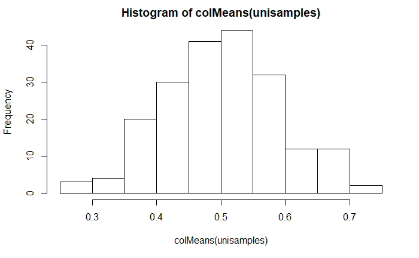

```r
hist(colMeans(unisamples))
```

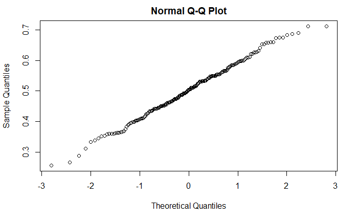

```r
qqnorm(colMeans(unisamples))
```

23)On the histogram, add a normal curve using the dnorm function. ( Note: to do this, plot the histogram with the argument freq=FALSE, so that the histogram draws the probability density, not the frequency.)

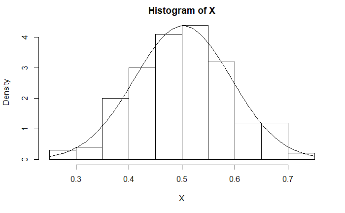

```r
X <- colMeans(unisamples)
hist(X, freq=FALSE)
curve(dnorm(x, mean=mean(X), sd=sd(X)), add=T)
```

24)Write a function that does all of the above(20 to 23), and call it PlotCLT.

```r
plotCLT <- function(n1=200, n2=10){
unisamples <- replicate(n1, runif(n2))
X <- colMeans(unisamples)
hist(X, freq=FALSE)
curve(dnorm(x, mean=mean(X), sd=sd(X)), add=T)
}
```